# Taller Factorial – Análisis factorial I y II con nueve indicadores educativos

¿Acceso y permanencia son dos dimensiones con nombre, o una sola?

Equipo: Luisa Fernández Velasco, David Santiago Lugo, Jairo Arturo Barrera, Gabriela Martínez Silva

2026-11-05

## Ficha técnica del caso

**Cliente:** Dirección de Cobertura y Equidad Territorial del Ministerio de Educación Nacional.

**Encargo:** El Ministerio quiere repartir recursos en **dos fondos**, uno de **acceso** (infraestructura y cupos) y otro de **permanencia y rendimiento** (tutorías, alimentación, acompañamiento). Pregunta si los indicadores municipales sostienen esas dos dimensiones o si en el fondo miden una sola «calidad educativa» del municipio.

**Datos:** `data/raw/educacion_limpio.csv`, registros municipio-año 2011–2024. Siguiendo la actividad práctica de las notas de clase, se escogen **9 de los 30 indicadores**.

# Parte A. Análisis factorial I

## Actividad 1. Las variables escogidas y el KMO

Escogemos las variables que, según el cliente, deberían compartir algo: **cuatro de acceso** (cobertura neta por nivel) y **cinco de permanencia y rendimiento** (aprobación por nivel, deserción y repitencia). Tres criterios guían la elección:

- **Sin indicadores agregados junto a sus niveles.** `COBERTURA_NETA` es un promedio ponderado de sus niveles; meter los dos repetiría la misma información.
- **Sin la identidad aprobación + reprobación + deserción ≈ 1.** Si entran las tres tasas generales, una se deduce de las otras dos y la matriz queda casi singular. Por eso no entra la reprobación.
- **Sin la población.** `POBLACIÓN_5_16` mide el tamaño del municipio, no sus condiciones; no esperamos que comparta nada con las demás.

```r
datos <- cargar_educacion(project_root)
vars <- c("COBERTURA_NETA_TRANSICIÓN", "COBERTURA_NETA_PRIMARIA", "COBERTURA_NETA_SECUNDARIA", "COBERTURA_NETA_MEDIA",
          "APROBACIÓN_PRIMARIA", "APROBACIÓN_SECUNDARIA", "APROBACIÓN_MEDIA", "DESERCIÓN", "REPITENCIA")
corta <- c(COBERTURA_NETA_TRANSICIÓN = "Cob. transición", COBERTURA_NETA_PRIMARIA = "Cob. primaria",
           COBERTURA_NETA_SECUNDARIA = "Cob. secundaria", COBERTURA_NETA_MEDIA = "Cob. media",
           APROBACIÓN_PRIMARIA = "Aprob. primaria", APROBACIÓN_SECUNDARIA = "Aprob. secundaria",
           APROBACIÓN_MEDIA = "Aprob. media", DESERCIÓN = "Deserción", REPITENCIA = "Repitencia")
grupo <- c(rep("Acceso", 4), rep("Permanencia y rendimiento", 5)); names(grupo) <- vars
X <- datos[, vars]
n <- nrow(X); p <- ncol(X)
stopifnot(p >= 4, p <= 10, !anyNA(X))
R <- cor(X)
panel <- resumen_panel(datos)

tab_vars <- data.frame(Variable = vars, Grupo = grupo, Media = colMeans(X), Desviacion = apply(X, 2, sd))
guardar_tabla(tab_vars, "variables_usadas.csv")
kable(tab_vars, digits = 3, row.names = FALSE, col.names = c("Variable", "Lo que esperamos que comparta", "Media", "Desviación"),
      caption = "Las 9 variables del taller (proporciones entre 0 y 1).")
```

Las 9 variables del taller (proporciones entre 0 y 1).

| Variable | Lo que esperamos que comparta | Media | Desviación |
| --- | --- | --- | --- |
| COBERTURA_NETA_TRANSICIÓN | Acceso | 0,578 | 0,154 |
| COBERTURA_NETA_PRIMARIA | Acceso | 0,826 | 0,166 |
| COBERTURA_NETA_SECUNDARIA | Acceso | 0,708 | 0,181 |
| COBERTURA_NETA_MEDIA | Acceso | 0,417 | 0,152 |
| APROBACIÓN_PRIMARIA | Permanencia y rendimiento | 0,931 | 0,048 |
| APROBACIÓN_SECUNDARIA | Permanencia y rendimiento | 0,879 | 0,077 |
| APROBACIÓN_MEDIA | Permanencia y rendimiento | 0,920 | 0,069 |
| DESERCIÓN | Permanencia y rendimiento | 0,035 | 0,021 |
| REPITENCIA | Permanencia y rendimiento | 0,039 | 0,037 |

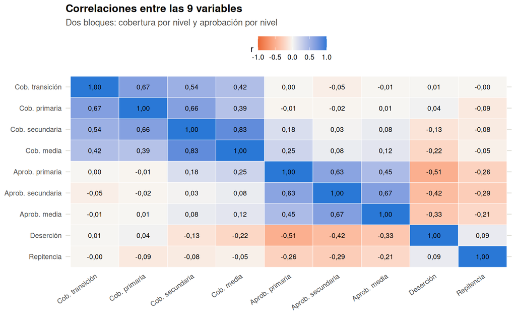

```r
kmo <- KMO(R)
kmo_tab <- data.frame(Variable = vars, KMO = as.numeric(kmo$MSAi))
guardar_tabla(rbind(kmo_tab, data.frame(Variable = "GLOBAL", KMO = kmo$MSA)), "kmo.csv")

cor_larga <- as.data.frame(as.table(R)) %>%
  mutate(Var1 = factor(corta[as.character(Var1)], levels = corta), Var2 = factor(corta[as.character(Var2)], levels = rev(corta)))
p_cor <- ggplot(cor_larga, aes(Var1, Var2, fill = Freq)) + geom_tile(color = "white") +
  geom_text(aes(label = coma(Freq, 2)), size = 3) +
  scale_fill_gradient2(low = paleta$naranja, mid = "#f7f6f2", high = paleta$azul, limits = c(-1, 1), name = "r") +
  tema + theme(axis.text.x = element_text(angle = 35, hjust = 1), panel.grid = element_blank()) +
  labs(title = "Correlaciones entre las 9 variables", subtitle = "Dos bloques: cobertura por nivel y aprobación por nivel", x = NULL, y = NULL)
print(p_cor)
```

```r
guardar_fig(p_cor, "correlaciones.png", 8, 6.5)
```

```r
kable(data.frame(Variable = c(vars, "**Global**"), KMO = coma(c(kmo$MSAi, kmo$MSA), 3)), row.names = FALSE, align = "lr",
      caption = "KMO por variable y global.")
```

KMO por variable y global.

| Variable | KMO |
| --- | --- |
| COBERTURA_NETA_TRANSICIÓN | 0,751 |
| COBERTURA_NETA_PRIMARIA | 0,576 |
| COBERTURA_NETA_SECUNDARIA | 0,597 |
| COBERTURA_NETA_MEDIA | 0,585 |
| APROBACIÓN_PRIMARIA | 0,756 |
| APROBACIÓN_SECUNDARIA | 0,672 |
| APROBACIÓN_MEDIA | 0,729 |
| DESERCIÓN | 0,826 |
| REPITENCIA | 0,810 |
| **Global** | 0,664 |

> ⭐ **Qué ve:** Son **13.802 registros municipio-año** de 1.123 municipios. El **KMO global es 0,664** y ninguna variable baja de 0,5 (la menor es COBERTURA_NETA_PRIMARIA, con 0,576). La matriz muestra dos bloques: la cobertura de los cuatro niveles se mueve junta (hasta 0,83) y la aprobación de los tres niveles también (hasta 0,67), pero entre bloques las correlaciones son casi nulas (en valor absoluto, a lo sumo 0,25).

> ⭐ **Qué significa para el cliente:** Hay algo común que buscar: el KMO queda entre «regular» y «bueno» según las referencias de clase. Ya se insinúa que lo común no es una sola cosa: el acceso y el rendimiento casi no se tocan.

> ⭐ **Qué decide él:** Seguir con el análisis factorial sobre estas 9 variables.

## Actividad 2. Un factor: parte común y parte propia

*`fa(datos, nfactors = 1, fm = "ml")` y gráfica de parte común y parte propia.*

Cada variable, en escala estándar, se parte en **carga × factor común + parte propia**, y su varianza en **carga² (parte común) + parte propia**.

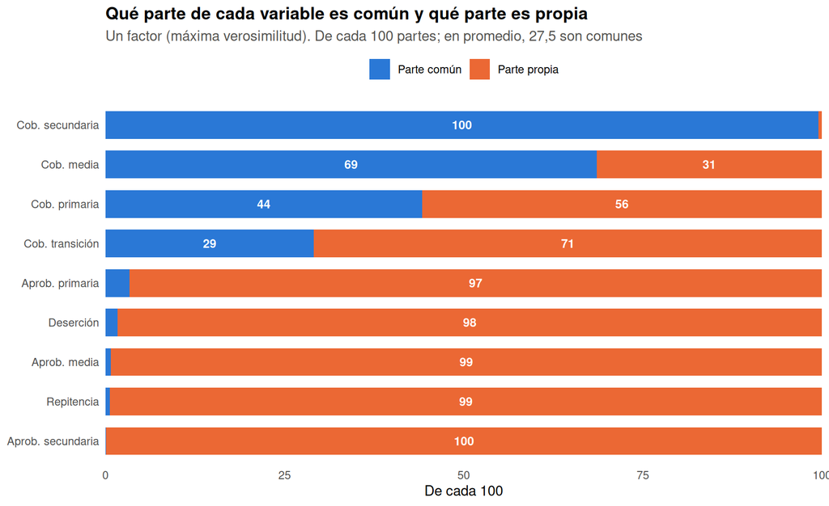

```r
f1 <- suppressWarnings(fa(X, nfactors = 1, fm = "ml"))
L1 <- as.numeric(f1$loadings[, 1]); names(L1) <- vars
if (L1["COBERTURA_NETA_SECUNDARIA"] < 0) L1 <- -L1
reparto <- data.frame(Variable = vars, Grupo = grupo, Carga = L1,
                      Comun = 100 * as.numeric(f1$communality), Propia = 100 * as.numeric(f1$uniquenesses))
guardar_tabla(reparto, "un_factor_comun_propia.csv")
pct_comun1 <- mean(reparto$Comun)

p_reparto <- reparto %>%
  select(Variable, `Parte común` = Comun, `Parte propia` = Propia) %>%
  pivot_longer(-Variable) %>%
  mutate(Variable = factor(corta[Variable], levels = corta[reparto$Variable[order(reparto$Comun)]]),
         name = factor(name, levels = c("Parte propia", "Parte común"))) %>%
  ggplot(aes(value, Variable, fill = name)) + geom_col(width = 0.7) +
  geom_text(aes(label = ifelse(value >= 6, coma(value, 0), "")), position = position_stack(vjust = 0.5),
            color = "white", fontface = "bold", size = 3.3) +
  scale_fill_manual(values = c(`Parte común` = paleta$azul, `Parte propia` = paleta$naranja),
                    breaks = c("Parte común", "Parte propia"), name = NULL) +
  scale_x_continuous(expand = c(0, 0)) + tema + theme(panel.grid.major.y = element_blank()) +
  labs(title = "Qué parte de cada variable es común y qué parte es propia",
       subtitle = paste0("Un factor (máxima verosimilitud). De cada 100 partes; en promedio, ", coma(pct_comun1, 1), " son comunes"),
       x = "De cada 100", y = NULL)
print(p_reparto)
```

```r
guardar_fig(p_reparto, "un_factor_comun_propia.png", 9, 5)
kable(reparto[, -2], digits = c(0, 3, 1, 1), row.names = FALSE, col.names = c("Variable", "Carga", "Parte común (de 100)", "Parte propia (de 100)"),
      caption = "Un factor (ML): carga, parte común y parte propia.")
```

Un factor (ML): carga, parte común y parte propia.

| Variable | Carga | Parte común (de 100) | Parte propia (de 100) |
| --- | --- | --- | --- |
| COBERTURA_NETA_TRANSICIÓN | 0,539 | 29,1 | 70,9 |
| COBERTURA_NETA_PRIMARIA | 0,665 | 44,2 | 55,8 |
| COBERTURA_NETA_SECUNDARIA | 0,998 | 99,5 | 0,5 |
| COBERTURA_NETA_MEDIA | 0,828 | 68,6 | 31,4 |
| APROBACIÓN_PRIMARIA | 0,183 | 3,3 | 96,7 |
| APROBACIÓN_SECUNDARIA | 0,029 | 0,1 | 99,9 |
| APROBACIÓN_MEDIA | 0,085 | 0,7 | 99,3 |
| DESERCIÓN | -0,130 | 1,7 | 98,3 |
| REPITENCIA | -0,078 | 0,6 | 99,4 |

> ⭐ **Qué ve:** El único factor lo definen las coberturas: secundaria (carga 1,00), media (0,83), primaria (0,66) y transición (0,54). Las cinco variables de permanencia y rendimiento tienen cargas de 0,03 a 0,18 en valor absoluto. En promedio, **27,5 de cada 100 partes** son comunes. La cobertura de secundaria queda con 99,5 de 100 partes comunes: el factor prácticamente *es* esa variable (con máxima verosimilitud llega al tope permitido, un caso límite que la actividad 4 de la Parte B revisa con otro método).

> ⭐ **Qué significa para el cliente:** Un solo factor no es una «calidad educativa general» del municipio: es **el acceso**. Todo lo de permanencia y rendimiento queda como parte propia.

> ⭐ **Qué decide él:** No usar un índice de un factor para repartir los dos fondos sin mirar lo que deja por fuera.

## Actividad 3. La variable que es casi toda propia

*¿Qué variable es casi toda propia? ¿Qué significa eso para su cliente?*

```r
propias <- reparto[order(-reparto$Propia), c("Variable", "Grupo", "Comun", "Propia")]
kable(propias, digits = 1, row.names = FALSE, col.names = c("Variable", "Grupo", "Parte común", "Parte propia"),
      caption = "Variables ordenadas de más a menos parte propia (un factor).")
```

Variables ordenadas de más a menos parte propia (un factor).

| Variable | Grupo | Parte común | Parte propia |
| --- | --- | --- | --- |
| APROBACIÓN_SECUNDARIA | Permanencia y rendimiento | 0,1 | 99,9 |
| REPITENCIA | Permanencia y rendimiento | 0,6 | 99,4 |
| APROBACIÓN_MEDIA | Permanencia y rendimiento | 0,7 | 99,3 |
| DESERCIÓN | Permanencia y rendimiento | 1,7 | 98,3 |
| APROBACIÓN_PRIMARIA | Permanencia y rendimiento | 3,3 | 96,7 |
| COBERTURA_NETA_TRANSICIÓN | Acceso | 29,1 | 70,9 |
| COBERTURA_NETA_PRIMARIA | Acceso | 44,2 | 55,8 |
| COBERTURA_NETA_MEDIA | Acceso | 68,6 | 31,4 |
| COBERTURA_NETA_SECUNDARIA | Acceso | 99,5 | 0,5 |

```r
# El costo de priorizar con el factor único: de los municipios-año con más deserción,
# ¿cuántos quedan fuera del 20 % con peor puntaje del factor?
f1s <- suppressWarnings(fa(X, nfactors = 1, fm = "ml", scores = "regression"))
s1 <- as.numeric(f1s$scores); if (cor(s1, X$COBERTURA_NETA_SECUNDARIA) < 0) s1 <- -s1
peor_factor <- s1 <= quantile(s1, 0.20)
g_des <- X$DESERCIÓN >= quantile(X$DESERCIÓN, 0.8)
g_rep <- X$REPITENCIA >= quantile(X$REPITENCIA, 0.8)
g_apr <- X$APROBACIÓN_SECUNDARIA <= quantile(X$APROBACIÓN_SECUNDARIA, 0.2)
costo <- data.frame(
  Grupo = c("20 % con más deserción", "20 % con más repitencia", "20 % con menos aprobación en secundaria"),
  Registros = c(sum(g_des), sum(g_rep), sum(g_apr)),
  Fuera = c(sum(g_des & !peor_factor), sum(g_rep & !peor_factor), sum(g_apr & !peor_factor)))
costo$Pct_fuera <- 100 * costo$Fuera / costo$Registros
guardar_tabla(costo, "costo_factor_unico.csv")
kable(costo, digits = 1, row.names = FALSE, col.names = c("Grupo prioritario", "Registros", "Fuera del 20 % peor del factor", "% fuera"),
      caption = "Si se prioriza con el factor único (20 % con peor puntaje), ¿cuántos de cada grupo se escapan?")
```

Si se prioriza con el factor único (20 % con peor puntaje), ¿cuántos de cada grupo se escapan?

| Grupo prioritario | Registros | Fuera del 20 % peor del factor | % fuera |
| --- | --- | --- | --- |
| 20 % con más deserción | 2.765 | 1.983 | 71,7 |
| 20 % con más repitencia | 2.764 | 2.110 | 76,3 |
| 20 % con menos aprobación en secundaria | 2.761 | 2.213 | 80,2 |

> ⭐ **Qué ve:** La más propia es **APROBACIÓN_SECUNDARIA**, con 99,9 de cada 100 partes propias, seguida de REPITENCIA (99,4) y APROBACIÓN_MEDIA (99,3). Todas las de permanencia y rendimiento superan 96. Si el Ministerio prioriza con el factor único, se le escapan **72 de cada 100** registros del grupo con más deserción y 76 de cada 100 del grupo con más repitencia; con un factor que no tuviera nada que ver con esos grupos se esperarían 80.

> ⭐ **Qué significa para el cliente:** Que la aprobación, la deserción y la repitencia sean casi todas propias **no significa que estén mal medidas**: significa que lo que miden no se puede deducir de la cobertura. Un municipio puede tener buena cobertura y mucha deserción, y un índice de acceso no lo ve: el factor único deja escapar casi tantos registros de deserción alta como un puntaje que no tuviera nada que ver con ella.

> ⭐ **Qué decide él:** La deserción y la repitencia se revisan directamente, no a través del factor de acceso.

## Actividad 4. ¿Alcanza con un factor? Correlaciones frente al producto de las cargas

*COmprobar si una habilidad alcanza: comparar las correlaciones con el producto de las cargas.*

Si un solo factor explica por qué las variables se mueven juntas, la correlación entre dos de ellas debe parecerse al producto de sus cargas: $r_{ij} \approx \lambda_i \lambda_j$.

```r
idx <- which(upper.tri(R), arr.ind = TRUE)
pares <- data.frame(Var1 = vars[idx[, 1]], Var2 = vars[idx[, 2]], Observada = R[idx], Producto = (L1 %o% L1)[idx])
pares$Diferencia <- pares$Observada - pares$Producto
pares$Tipo <- with(pares, ifelse(grupo[Var1] == "Acceso" & grupo[Var2] == "Acceso", "Las dos de acceso",
                          ifelse(grupo[Var1] != "Acceso" & grupo[Var2] != "Acceso", "Las dos de permanencia", "Una de cada grupo")))
pares <- pares[order(-abs(pares$Diferencia)), ]
guardar_tabla(pares, "un_factor_correlaciones_vs_producto.csv")
kable(head(pares[, 1:5], 8), digits = 3, row.names = FALSE,
      col.names = c("Variable 1", "Variable 2", "Correlación observada", "Producto de cargas", "Diferencia"),
      caption = paste0("Las 8 parejas (de ", nrow(pares), ") que un factor reproduce peor."))
```

Las 8 parejas (de 36) que un factor reproduce peor.

| Variable 1 | Variable 2 | Correlación observada | Producto de cargas | Diferencia |
| --- | --- | --- | --- | --- |
| APROBACIÓN_SECUNDARIA | APROBACIÓN_MEDIA | 0,670 | 0,002 | 0,668 |
| APROBACIÓN_PRIMARIA | APROBACIÓN_SECUNDARIA | 0,630 | 0,005 | 0,625 |
| APROBACIÓN_PRIMARIA | DESERCIÓN | -0,511 | -0,024 | -0,487 |
| APROBACIÓN_PRIMARIA | APROBACIÓN_MEDIA | 0,446 | 0,016 | 0,430 |
| APROBACIÓN_SECUNDARIA | DESERCIÓN | -0,416 | -0,004 | -0,412 |
| APROBACIÓN_MEDIA | DESERCIÓN | -0,335 | -0,011 | -0,324 |
| COBERTURA_NETA_TRANSICIÓN | COBERTURA_NETA_PRIMARIA | 0,668 | 0,358 | 0,310 |
| APROBACIÓN_SECUNDARIA | REPITENCIA | -0,295 | -0,002 | -0,292 |

```r
res_grupo <- pares %>% group_by(Tipo) %>% summarise(Parejas = n(), Diferencia_media = mean(abs(Diferencia)), Diferencia_maxima = max(abs(Diferencia)), .groups = "drop")
kable(res_grupo, digits = 3, col.names = c("Tipo de pareja", "Parejas", "|Diferencia| media", "|Diferencia| máxima"),
      caption = "Diferencias por tipo de pareja.")
```

Diferencias por tipo de pareja.

| Tipo de pareja | Parejas | \|Diferencia\| media | \|Diferencia\| máxima |
| --- | --- | --- | --- |
| Las dos de acceso | 6 | 0,082 | 0,310 |
| Las dos de permanencia | 10 | 0,376 | 0,668 |
| Una de cada grupo | 20 | 0,053 | 0,136 |

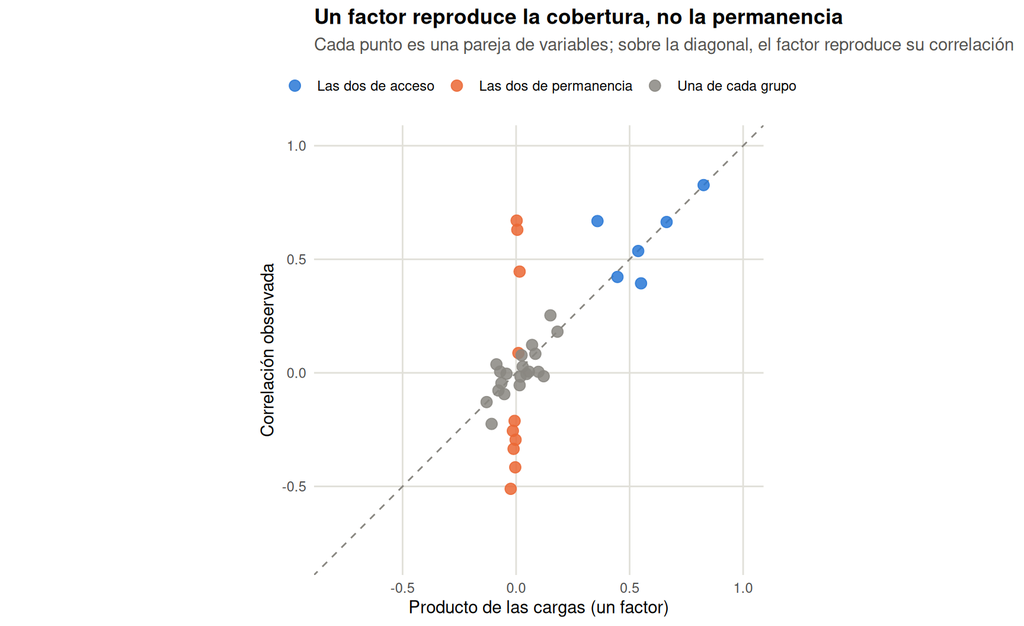

```r
p_prod <- ggplot(pares, aes(Producto, Observada, color = Tipo)) +
  geom_abline(slope = 1, intercept = 0, color = paleta$gris, linetype = "dashed") +
  geom_point(size = 3, alpha = 0.85) +
  scale_color_manual(values = c(`Las dos de acceso` = paleta$azul, `Una de cada grupo` = paleta$gris, `Las dos de permanencia` = paleta$naranja), name = NULL) +
  coord_equal(xlim = c(-0.8, 1), ylim = c(-0.8, 1)) + tema + theme(panel.grid.major.x = element_line(color = paleta$rejilla)) +
  labs(title = "Un factor reproduce la cobertura, no la permanencia",
       subtitle = "Cada punto es una pareja de variables; sobre la diagonal, el factor reproduce su correlación",
       x = "Producto de las cargas (un factor)", y = "Correlación observada")
print(p_prod)
```

```r
guardar_fig(p_prod, "un_factor_correlaciones_vs_producto.png", 7.5, 6.5)
```

> ⭐ **Qué ve:** Entre las variables de acceso la cuenta casi cuadra (diferencia media 0,082). Entre las de permanencia no: la pareja peor reproducida es **APROBACIÓN_SECUNDARIA y APROBACIÓN_MEDIA**, que se correlacionan 0,67 mientras el factor reproduce 0,00. En la gráfica, los puntos naranja forman una columna en cero: el factor les asigna correlación casi nula aunque en los datos van de -0,51 a 0,67.

> ⭐ **Qué significa para el cliente:** **Un factor no alcanza.** A diferencia del ejemplo de clase, donde una habilidad reproducía casi todo, aquí queda sin explicar todo lo que une a la aprobación, la deserción y la repitencia entre sí.

> ⭐ **Qué decide él:** Probar con dos factores.

## Actividad 5. ¿Y si le pedimos dos?

*Probar con dos. ¿La segunda es una habilidad con sentido, o es una sola variable?*

```r
# Orienta una solución de dos factores: primero el de acceso, luego el de rendimiento, los dos con «mayor = mejor»
orientar <- function(f) {
  L <- unclass(f$loadings)
  acc <- which.max(abs(L["COBERTURA_NETA_SECUNDARIA", ])); orden <- c(acc, 3 - acc)
  L <- L[, orden]
  s <- c(sign(L["COBERTURA_NETA_SECUNDARIA", 1]), sign(L["APROBACIÓN_SECUNDARIA", 2]))
  L <- sweep(L, 2, s, `*`)
  Phi <- if (is.null(f$Phi)) diag(2) else f$Phi[orden, orden] * outer(s, s)
  colnames(L) <- c("Acceso", "Rendimiento"); dimnames(Phi) <- list(colnames(L), colnames(L))
  list(L = L, Phi = Phi, h2 = f$communality)
}
error_modelo <- function(L, Phi = diag(ncol(L))) { E <- R - L %*% Phi %*% t(L); abs(E[upper.tri(E)]) }
pareja_peor <- function(L, Phi = diag(ncol(L))) {
  E <- abs(R - L %*% Phi %*% t(L)); E[!upper.tri(E)] <- 0
  w <- which(E == max(E), arr.ind = TRUE)[1, ]; paste(vars[w[1]], "y", vars[w[2]])
}

f2 <- suppressWarnings(fa(X, nfactors = 2, fm = "ml", rotate = "oblimin"))
o2 <- orientar(f2)
e1 <- error_modelo(matrix(L1)); e2 <- error_modelo(o2$L, o2$Phi)
uno_dos <- data.frame(Modelo = c("1 factor", "2 factores"), Parte_comun = c(pct_comun1, 100 * mean(o2$h2)),
                      Error_medio = c(mean(e1), mean(e2)), Error_maximo = c(max(e1), max(e2)), Pct_parejas_error_010 = 100 * c(mean(e1 > 0.1), mean(e2 > 0.1)))
guardar_tabla(uno_dos, "uno_vs_dos_factores.csv")
kable(uno_dos, digits = 3, col.names = c("Modelo", "Parte común media (de 100)", "Error medio", "Error máximo", "% de parejas con error > 0,10"),
      caption = "Uno frente a dos factores (ML, oblimin): cuánto de las correlaciones queda sin explicar.")
```

Uno frente a dos factores (ML, oblimin): cuánto de las correlaciones queda sin explicar.

| Modelo | Parte común media (de 100) | Error medio | Error máximo | % de parejas con error > 0,10 |
| --- | --- | --- | --- | --- |
| 1 factor | 27,530 | 0,148 | 0,668 | 41,667 |
| 2 factores | 51,703 | 0,041 | 0,301 | 8,333 |

```r
tab2 <- data.frame(Variable = vars, round(o2$L, 3), Parte_comun = round(100 * o2$h2, 1))
guardar_tabla(tab2, "cargas_2_factores_ml_oblimin.csv")
kable(tab2, row.names = FALSE, col.names = c("Variable", "Factor 1 (Acceso)", "Factor 2 (Rendimiento)", "Parte común (de 100)"),
      caption = "Dos factores (ML, oblimin).")
```

Dos factores (ML, oblimin).

| Variable | Factor 1 (Acceso) | Factor 2 (Rendimiento) | Parte común (de 100) |
| --- | --- | --- | --- |
| COBERTURA_NETA_TRANSICIÓN | 0,550 | -0,099 | 30,1 |
| COBERTURA_NETA_PRIMARIA | 0,674 | -0,091 | 45,0 |
| COBERTURA_NETA_SECUNDARIA | 0,998 | -0,002 | 99,5 |
| COBERTURA_NETA_MEDIA | 0,819 | 0,087 | 69,3 |
| APROBACIÓN_PRIMARIA | 0,107 | 0,707 | 52,8 |
| APROBACIÓN_SECUNDARIA | -0,067 | 0,901 | 80,4 |
| APROBACIÓN_MEDIA | 0,009 | 0,716 | 51,3 |
| DESERCIÓN | -0,077 | -0,503 | 26,7 |
| REPITENCIA | -0,045 | -0,312 | 10,2 |

```r
n_f2 <- sum(abs(o2$L[, 2]) >= 0.3)
peor2 <- pareja_peor(o2$L, o2$Phi)
```

> ⭐ **Qué ve:** Con dos factores la parte común media sube de 27,5 a **51,7 de cada 100**, y el error medio baja de 0,148 a 0,041 (el error máximo baja de 0,668 a 0,301, en la pareja COBERTURA_NETA_TRANSICIÓN y COBERTURA_NETA_PRIMARIA, y solo 8,3 % de las parejas fallan por más de 0,10). El segundo factor lo definen **5 variables** con carga de 0,3 o más en valor absoluto: aprobación en secundaria (0,90), en media (0,72) y en primaria (0,71), y en sentido contrario la deserción (-0,50) y la repitencia (-0,31).

> ⭐ **Qué significa para el cliente:** A diferencia de las notas de clase, donde la segunda habilidad caía casi entera sobre lectura, aquí **el segundo factor no es una sola variable**: es la aprobación de los tres niveles, con la deserción y la repitencia del lado opuesto. Tiene sentido llamarlo **rendimiento y permanencia**. Aun así, la deserción y la repitencia conservan 73 y 90 de cada 100 partes propias.

> ⭐ **Qué decide él:** Dos factores, Acceso y Rendimiento, son una base razonable para dos fondos. La Parte B comprueba si sobreviven al giro y al cambio de método.

# Parte B. Análisis factorial II

## Actividad 1. Dos factores sin girar

*Sacar dos habilidades sin girar y mirar si se pueden nombrar.*

```r
f2_sin <- suppressWarnings(fa(X, nfactors = 2, fm = "ml", rotate = "none"))
o_sin <- orientar(f2_sin)
tab_sin <- data.frame(Variable = vars, round(o_sin$L, 3))
guardar_tabla(tab_sin, "cargas_2_factores_sin_girar.csv")
kable(tab_sin, row.names = FALSE, col.names = c("Variable", "Primer factor", "Segundo factor"),
      caption = "Dos factores sin girar (ML, rotate = \"none\").")
```

Dos factores sin girar (ML, rotate = “none”).

| Variable | Primer factor | Segundo factor |
| --- | --- | --- |
| COBERTURA_NETA_TRANSICIÓN | 0,539 | -0,099 |
| COBERTURA_NETA_PRIMARIA | 0,664 | -0,091 |
| COBERTURA_NETA_SECUNDARIA | 0,997 | -0,004 |
| COBERTURA_NETA_MEDIA | 0,828 | 0,085 |
| APROBACIÓN_PRIMARIA | 0,184 | 0,703 |
| APROBACIÓN_SECUNDARIA | 0,031 | 0,896 |
| APROBACIÓN_MEDIA | 0,086 | 0,711 |
| DESERCIÓN | -0,131 | -0,500 |
| REPITENCIA | -0,079 | -0,310 |

```r
cruzadas <- function(L) sum(rowSums(abs(L) >= 0.3) >= 2)
```

> ⭐ **Qué ve:** Sin girar, el primer factor ya reúne la cobertura (secundaria 1,00, media 0,83) y el segundo la aprobación (secundaria 0,90). Ninguna variable carga 0,3 o más en los dos factores.

> ⭐ **Qué significa para el cliente:** Aquí los factores **se pueden nombrar sin girar**, al revés que en clase. La razón está en la actividad 1: los dos bloques casi no se correlacionan, así que el primer factor no tiene que llevarse un pedazo del otro bloque.

> ⭐ **Qué decide él:** Girar de todas formas, para confirmar que los nombres no dependen del giro.

## Actividad 2. Varimax y oblimin: la parte común no cambia

*Girarlas de las dos maneras (`rotate = "varimax"` y `rotate = "oblimin"`). Comprobar que la parte común de cada variable no cambia.*

```r
f2_vari <- suppressWarnings(fa(X, nfactors = 2, fm = "ml", rotate = "varimax"))
o_vari <- orientar(f2_vari)
h2_giros <- data.frame(Variable = vars, Sin_girar = f2_sin$communality, Varimax = f2_vari$communality, Oblimin = f2$communality)
guardar_tabla(h2_giros, "comunalidades_por_giro.csv")
guardar_tabla(data.frame(Variable = vars, round(o_vari$L, 3)), "cargas_2_factores_ml_varimax.csv")
dif_h2 <- max(abs(h2_giros$Varimax - h2_giros$Sin_girar), abs(h2_giros$Oblimin - h2_giros$Sin_girar))
kable(h2_giros, digits = 4, row.names = FALSE, col.names = c("Variable", "Sin girar", "Varimax", "Oblimin"),
      caption = "Parte común (comunalidad) de cada variable con cada giro.")
```

Parte común (comunalidad) de cada variable con cada giro.

| Variable | Sin girar | Varimax | Oblimin |
| --- | --- | --- | --- |
| COBERTURA_NETA_TRANSICIÓN | 0,3005 | 0,3005 | 0,3005 |
| COBERTURA_NETA_PRIMARIA | 0,4499 | 0,4499 | 0,4499 |
| COBERTURA_NETA_SECUNDARIA | 0,9950 | 0,9950 | 0,9950 |
| COBERTURA_NETA_MEDIA | 0,6932 | 0,6932 | 0,6932 |
| APROBACIÓN_PRIMARIA | 0,5279 | 0,5279 | 0,5279 |
| APROBACIÓN_SECUNDARIA | 0,8040 | 0,8040 | 0,8040 |
| APROBACIÓN_MEDIA | 0,5133 | 0,5133 | 0,5133 |
| DESERCIÓN | 0,2671 | 0,2671 | 0,2671 |
| REPITENCIA | 0,1023 | 0,1023 | 0,1023 |

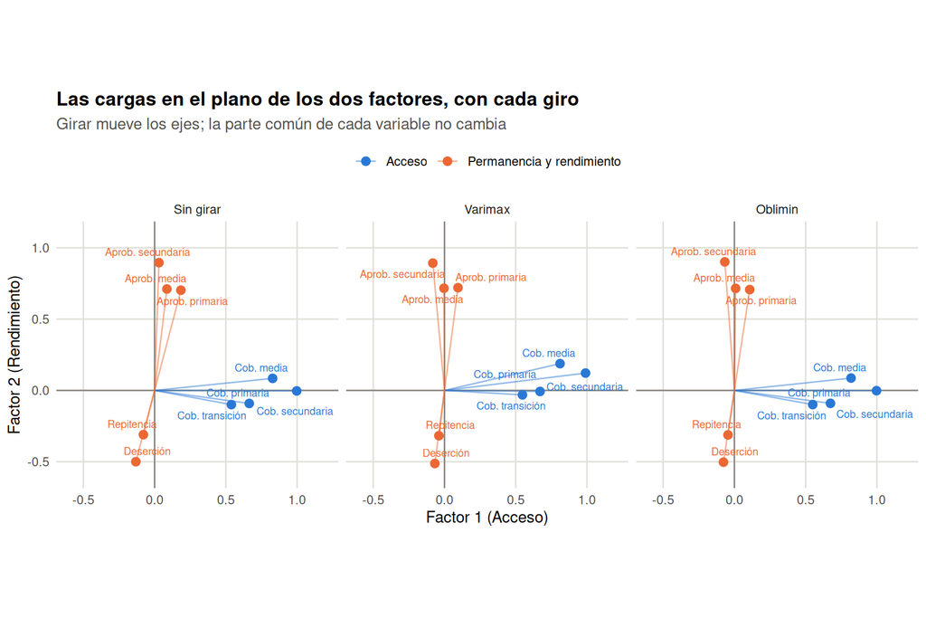

```r
# El plano de cargas: dónde queda cada variable con cada giro
plano <- bind_rows(lapply(list(`Sin girar` = o_sin, Varimax = o_vari, Oblimin = o2), function(o)
  data.frame(Variable = corta[vars], Grupo = grupo, Acceso = o$L[, 1], Rendimiento = o$L[, 2])), .id = "Giro")
plano$Giro <- factor(plano$Giro, levels = c("Sin girar", "Varimax", "Oblimin"))
guardar_tabla(plano, "plano_de_cargas.csv")
p_plano <- ggplot(plano, aes(Acceso, Rendimiento, color = Grupo)) +
  geom_hline(yintercept = 0, color = paleta$gris) + geom_vline(xintercept = 0, color = paleta$gris) +
  geom_segment(aes(x = 0, y = 0, xend = Acceso, yend = Rendimiento), alpha = 0.5) + geom_point(size = 2.5) +
  ggrepel::geom_text_repel(aes(label = Variable), size = 2.6, show.legend = FALSE, min.segment.length = 1, seed = 1) +
  scale_color_manual(values = c(Acceso = paleta$azul, `Permanencia y rendimiento` = paleta$naranja), name = NULL) +
  facet_wrap(~Giro) + coord_equal(xlim = c(-0.6, 1.2), ylim = c(-0.6, 1.1)) + tema +
  theme(panel.grid.major.x = element_line(color = paleta$rejilla)) +
  labs(title = "Las cargas en el plano de los dos factores, con cada giro", subtitle = "Girar mueve los ejes; la parte común de cada variable no cambia",
       x = "Factor 1 (Acceso)", y = "Factor 2 (Rendimiento)")
print(p_plano)
```

```r
guardar_fig(p_plano, "plano_de_cargas.png", 11, 5)
```

> ⭐ **Qué ve:** La parte común de cada variable es **la misma con los tres giros**: la diferencia máxima es menor que 0,0001. En la gráfica, sin girar y con varimax cada variable queda a la misma distancia del origen (la raíz de su parte común) y solo cambian los ejes; con oblimin los ejes dejan de ser perpendiculares, pero la parte común tampoco cambia. Como los dos bloques ya estaban casi sobre los ejes, los tres paneles se ven casi iguales.

> ⭐ **Qué significa para el cliente:** Girar **no agrega ni quita información**: solo cambia desde dónde se mira. Y en estos datos, cualquier giro lleva a los mismos dos nombres.

> ⭐ **Qué decide él:** Los nombres Acceso y Rendimiento no son producto de escoger un giro.

## Actividad 3. ¿Cuánto van juntos los dos factores?

*¿Cuánto van juntas las dos habilidades con el giro que lo permite?*

```r
phi <- o2$Phi[1, 2]
kable(round(o2$Phi, 3), caption = "Correlación entre los dos factores con oblimin (ML).")
```

Correlación entre los dos factores con oblimin (ML).

|  | Acceso | Rendimiento |
| --- | --- | --- |
| Acceso | 1,000 | 0,107 |
| Rendimiento | 0,107 | 1,000 |

```r
# Si cada fondo toma el 20 % con peor puntaje en su factor, ¿cuántos municipios-año caen en los dos?
f2s <- suppressWarnings(fa(X, nfactors = 2, fm = "ml", rotate = "oblimin", scores = "regression"))
L2s <- unclass(f2s$loadings); S <- f2s$scores
acc <- which.max(abs(L2s["COBERTURA_NETA_SECUNDARIA", ])); ren <- 3 - acc
s_acc <- S[, acc] * sign(L2s["COBERTURA_NETA_SECUNDARIA", acc]); s_ren <- S[, ren] * sign(L2s["APROBACIÓN_SECUNDARIA", ren])
b_acc <- s_acc <= quantile(s_acc, 0.2); b_ren <- s_ren <= quantile(s_ren, 0.2)
solape <- data.frame(Grupo = c("Solo fondo de acceso", "En los dos fondos", "Solo fondo de rendimiento"),
                     Registros = c(sum(b_acc & !b_ren), sum(b_acc & b_ren), sum(b_ren & !b_acc)))
solape$Pct_del_cupo <- 100 * solape$Registros / sum(b_acc)
guardar_tabla(solape, "solapamiento_fondos.csv")
kable(solape, digits = 1, row.names = FALSE, col.names = c("Grupo", "Registros", "% del cupo de un fondo"),
      caption = "Cada fondo toma el 20 % con peor puntaje en su factor. Si los factores fueran independientes, se esperaría 20 % en los dos.")
```

Cada fondo toma el 20 % con peor puntaje en su factor. Si los factores fueran independientes, se esperaría 20 % en los dos.

| Grupo | Registros | % del cupo de un fondo |
| --- | --- | --- |
| Solo fondo de acceso | 2.091 | 75,7 |
| En los dos fondos | 670 | 24,3 |
| Solo fondo de rendimiento | 2.091 | 75,7 |

> ⭐ **Qué ve:** Con oblimin, que deja que los factores vayan juntos si los datos lo piden, Acceso y Rendimiento se correlacionan **0,11**. Si cada fondo toma el 20 % con peor puntaje, coinciden 670 registros: **24,3 %** del cupo de cada fondo, cerca del 20 % que se esperaría si los factores fueran independientes.

> ⭐ **Qué significa para el cliente:** En las notas de clase las dos habilidades iban juntas 0,79 y tres de cada cuatro candidatos salían escogidos en los dos perfiles. Aquí pasa lo contrario: **un municipio puede tener buen acceso y bajo rendimiento, o al revés**, y los dos fondos llegan a municipios distintos.

> ⭐ **Qué decide él:** Dos fondos no serían el mismo fondo con dos nombres.

## Actividad 4. ¿Se mantiene con otro método?

*Cambiar el método (`fm = "minres"`). ¿La separación se mantiene?*

```r
tuck <- function(a, b) abs(sum(a * b)) / sqrt(sum(a^2) * sum(b^2))
f2_mr <- suppressWarnings(fa(X, nfactors = 2, fm = "minres", rotate = "oblimin"))
f2_pa <- suppressWarnings(fa(X, nfactors = 2, fm = "pa", rotate = "oblimin"))
metodos <- list(`Máxima verosimilitud (ml)` = o2, `Residuos mínimos (minres)` = orientar(f2_mr), `Ejes principales (pa)` = orientar(f2_pa))
comp_met <- do.call(rbind, lapply(names(metodos), function(m) {
  o <- metodos[[m]]
  data.frame(Metodo = m, Parte_comun = 100 * mean(o$h2), Phi = o$Phi[1, 2],
             Congruencia_Acceso = tuck(o$L[, 1], o2$L[, 1]), Congruencia_Rendimiento = tuck(o$L[, 2], o2$L[, 2]),
             Max_parte_comun = 100 * max(o$h2), Variable_max = vars[which.max(o$h2)])
}))
guardar_tabla(comp_met, "comparacion_metodos.csv")
kable(comp_met, digits = 3, row.names = FALSE,
      col.names = c("Método", "Parte común media", "Φ", "Congruencia Acceso con ML", "Congruencia Rendimiento con ML", "Parte común máxima", "Variable"),
      caption = "Dos factores (oblimin) con tres métodos de estimación. Congruencia de Tucker: 1 = mismas cargas.")
```

Dos factores (oblimin) con tres métodos de estimación. Congruencia de Tucker: 1 = mismas cargas.

| Método | Parte común media | Φ | Congruencia Acceso con ML | Congruencia Rendimiento con ML | Parte común máxima | Variable |
| --- | --- | --- | --- | --- | --- | --- |
| Máxima verosimilitud (ml) | 51,703 | 0,107 | 1,000 | 1,000 | 99,501 | COBERTURA_NETA_SECUNDARIA |
| Residuos mínimos (minres) | 51,782 | 0,099 | 0,994 | 0,997 | 92,907 | COBERTURA_NETA_SECUNDARIA |
| Ejes principales (pa) | 51,762 | 0,100 | 0,994 | 0,997 | 92,533 | COBERTURA_NETA_SECUNDARIA |

```r
guardar_tabla(data.frame(Variable = vars, round(metodos[[2]]$L, 3), Parte_comun = round(100 * metodos[[2]]$h2, 1)), "cargas_2_factores_minres_oblimin.csv")
```

> ⭐ **Qué ve:** Con MinRes y con ejes principales las cargas son casi las mismas que con máxima verosimilitud (congruencia de 0,994 o más), la correlación entre factores sigue baja (0,11; 0,10; 0,10) y la parte común media apenas cambia. La diferencia está en la cobertura de secundaria: con máxima verosimilitud llega al tope (99,5 de 100) y con MinRes queda en 92,9.

> ⭐ **Qué significa para el cliente:** **La separación se mantiene.** En las notas de clase la segunda habilidad cambiaba de forma con el método y por eso no se podía nombrar; aquí no cambia, y eso le da peso a los nombres. Lo único frágil es que la secundaria quede «toda» en el factor de acceso: es la variable que mejor resume a las demás coberturas (está entre primaria y media), no una prueba de que el acceso sea solo secundaria.

> ⭐ **Qué decide él:** Los dos fondos pueden apoyarse en Acceso y Rendimiento con cualquiera de los tres métodos.

## Actividad 5. ¿Cuántos factores caben como máximo?

*Con el número de variables, ¿cuántas habilidades caben como máximo?*

Con $p$ variables hay $p(p-1)/2$ correlaciones. Con $k$ factores, lo que el modelo deja libre para ponerse a prueba son
$$\text{grados de
libertad} = \frac{(p-k)^2 - (p+k)}{2}.$$
Si da negativo, el modelo tiene más incógnitas que datos y no se puede estimar.

```r
gl <- data.frame(Factores = 1:(p - 1), Correlaciones = p * (p - 1) / 2)
gl$Grados_de_libertad <- ((p - gl$Factores)^2 - (p + gl$Factores)) / 2
k_max <- max(gl$Factores[gl$Grados_de_libertad >= 0])
guardar_tabla(gl, "grados_de_libertad.csv")
kable(gl, row.names = FALSE, col.names = c("Factores", "Correlaciones", "Grados de libertad"),
      caption = paste0("Grados de libertad con ", p, " variables."))
```

Grados de libertad con 9 variables.

| Factores | Correlaciones | Grados de libertad |
| --- | --- | --- |
| 1 | 36 | 27 |
| 2 | 36 | 19 |
| 3 | 36 | 12 |
| 4 | 36 | 6 |
| 5 | 36 | 1 |
| 6 | 36 | -3 |
| 7 | 36 | -6 |
| 8 | 36 | -8 |

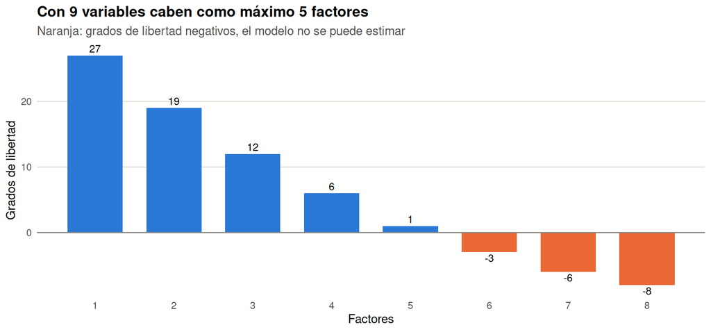

```r
p_gl <- ggplot(gl, aes(Factores, Grados_de_libertad, fill = Grados_de_libertad >= 0)) + geom_col(width = 0.7) +
  geom_hline(yintercept = 0, color = paleta$gris) +
  geom_text(aes(label = Grados_de_libertad, vjust = ifelse(Grados_de_libertad >= 0, -0.4, 1.3)), size = 3.3) +
  scale_fill_manual(values = c(`TRUE` = paleta$azul, `FALSE` = paleta$naranja), guide = "none") +
  scale_x_continuous(breaks = gl$Factores) + tema +
  labs(title = paste0("Con ", p, " variables caben como máximo ", k_max, " factores"),
       subtitle = "Naranja: grados de libertad negativos, el modelo no se puede estimar", x = "Factores", y = "Grados de libertad")
print(p_gl)
```

```r
guardar_fig(p_gl, "grados_de_libertad.png", 8, 4.2)

# Cuántos vale la pena sacar: análisis paralelo y ajuste de cada solución posible
invisible(capture.output(pa <- fa.parallel(X, fa = "fa", fm = "ml", n.iter = 30, plot = FALSE)))
ajuste_k <- do.call(rbind, lapply(1:k_max, function(k) {
  f <- suppressWarnings(fa(X, nfactors = k, fm = "minres", rotate = if (k == 1) "none" else "oblimin"))
  data.frame(Factores = k, Grados_de_libertad = gl$Grados_de_libertad[k], Parte_comun = 100 * mean(f$communality),
             Error_maximo = max(abs(f$residual[upper.tri(f$residual)])), Partes_comunes_mayores_99 = sum(f$communality > 0.99))
}))
guardar_tabla(ajuste_k, "ajuste_por_numero_de_factores.csv")
kable(ajuste_k, digits = 3, row.names = FALSE,
      col.names = c("Factores", "Grados de libertad", "Parte común media", "Error máximo", "Variables con parte común > 99"),
      caption = paste0("Cada solución posible (MinRes). El análisis paralelo sugiere ", pa$nfact, " factores."))
```

Cada solución posible (MinRes). El análisis paralelo sugiere 3 factores.

| Factores | Grados de libertad | Parte común media | Error máximo | Variables con parte común > 99 |
| --- | --- | --- | --- | --- |
| 1 | 27 | 27,350 | 0,607 | 0 |
| 2 | 19 | 51,782 | 0,177 | 0 |
| 3 | 12 | 61,275 | 0,088 | 1 |
| 4 | 6 | 70,001 | 0,049 | 2 |
| 5 | 1 | 71,510 | 0,006 | 3 |

> ⭐ **Qué ve:** Con 9 variables hay 36 correlaciones y caben como máximo **5 factores** (con 6 los grados de libertad dan -3). El análisis paralelo sugiere 3. Con dos factores (MinRes) el error máximo baja de 0,607 a 0,177; un tercero lo lleva a 0,088, pero ya deja 1 variable(s) con parte común por encima de 99 de 100 (un caso límite), y desde ahí cada factor agrega casos límite.

> ⭐ **Qué significa para el cliente:** Con 9 variables el límite aritmético (5) no es el que manda, a diferencia del caso de clase con cinco módulos. Lo que manda es que **dos factores ya explican casi todo lo que las variables comparten** y se pueden nombrar; un tercero, como sugiere el análisis paralelo, solo partiría uno de los dos bloques y empieza a forzar el modelo, sin cambiar la decisión de dos fondos.

> ⭐ **Qué decide él:** Trabajar con dos factores.

# Conclusión: lo que le entregamos al cliente

```r
resumen <- data.frame(
  Actividad = c("AF I · 1", "AF I · 2", "AF I · 3", "AF I · 4", "AF I · 5", "AF II · 1", "AF II · 2", "AF II · 3", "AF II · 4", "AF II · 5"),
  Resultado = c(
    paste0(p, " variables; KMO ", coma(kmo$MSA, 3), ", ninguna por debajo de 0,5"),
    paste0("Un factor = acceso; ", coma(pct_comun1, 1), " de cada 100 partes comunes en promedio"),
    paste0(propias$Variable[1], " es ", coma(propias$Propia[1], 1), " % propia; el factor único deja fuera ", coma(costo$Pct_fuera[1], 0), " % del grupo con más deserción"),
    paste0("Un factor no alcanza: error máximo ", coma(max(e1), 2), " (", pares$Var1[1], " y ", pares$Var2[1], ")"),
    paste0("Dos factores: Acceso y Rendimiento; error máximo ", coma(max(e2), 3)),
    "Sin girar ya se pueden nombrar",
    paste0("Varimax y oblimin: misma parte común (diferencia máxima ", if (dif_h2 < 1e-4) "< 0,0001" else coma(dif_h2, 4), ")"),
    paste0("Φ = ", coma(phi, 2), "; los dos fondos coinciden en ", coma(solape$Pct_del_cupo[2], 1), " % del cupo"),
    paste0("MinRes y ejes principales: congruencia ≥ ", coma(min(comp_met[, 4:5]), 3)),
    paste0("Caben hasta ", k_max, " factores; dos bastan")))
guardar_tabla(resumen, "resumen_final.csv")
kable(resumen, caption = "Resumen de las diez actividades.")
```

Resumen de las diez actividades.

| Actividad | Resultado |
| --- | --- |
| AF I · 1 | 9 variables; KMO 0,664, ninguna por debajo de 0,5 |
| AF I · 2 | Un factor = acceso; 27,5 de cada 100 partes comunes en promedio |
| AF I · 3 | APROBACIÓN_SECUNDARIA es 99,9 % propia; el factor único deja fuera 72 % del grupo con más deserción |
| AF I · 4 | Un factor no alcanza: error máximo 0,67 (APROBACIÓN_SECUNDARIA y APROBACIÓN_MEDIA) |
| AF I · 5 | Dos factores: Acceso y Rendimiento; error máximo 0,301 |
| AF II · 1 | Sin girar ya se pueden nombrar |
| AF II · 2 | Varimax y oblimin: misma parte común (diferencia máxima < 0,0001) |
| AF II · 3 | Φ = 0,11; los dos fondos coinciden en 24,3 % del cupo |
| AF II · 4 | MinRes y ejes principales: congruencia ≥ 0,994 |
| AF II · 5 | Caben hasta 5 factores; dos bastan |

Al Ministerio le respondemos:

- **Los indicadores no miden una sola «calidad educativa».** Un factor solo recoge el acceso; la aprobación, la deserción y la repitencia quedan casi enteras por fuera.
- **Sí hay dos dimensiones con nombre: Acceso y Rendimiento.** Cada una la define un grupo de variables, no una sola. Se sostienen sin girar, con varimax, con oblimin y con tres métodos de estimación.
- **Y casi no van juntas** (0,11): un municipio puede tener buena cobertura y bajo rendimiento. Los dos fondos llegarían a municipios distintos.
- **La deserción y la repitencia tienen mucho propio** incluso con dos factores: hay que mirarlas directamente, no solo a través del puntaje de rendimiento.
- **La decisión:** dos fondos, uno de acceso y otro de rendimiento y permanencia, y la deserción como alerta aparte.

**Límites:** las filas de un mismo municipio en distintos años no son independientes; las 9 variables son una selección nuestra (el análisis con todas está en el informe del Corte 2); las variables son proporciones acotadas y asimétricas, y la máxima verosimilitud supone normalidad; los nombres de los factores son interpretación nuestra.

# Preguntas conceptuales

**Análisis factorial I**

1. **Parte común y parte propia.** La parte común (carga²) es la porción de las diferencias en una variable que comparte con las demás a través del factor; la parte propia es lo que mide solo esa variable, más su error. Con un factor, la cobertura de media es 69 % común y la deserción 2 %.
2. **Escritura tiene 15 de cada 100 partes comunes, ¿está mal hecho el módulo?** No. Mide algo que los otros módulos no miden. Aquí la deserción es casi toda propia y no por eso está mal medida: mide algo que la cobertura no dice.
3. **Si la correlación es casi igual al producto de las cargas,** una sola habilidad alcanza para explicar por qué los módulos se mueven juntos. En nuestras variables no pasa con un factor (error máximo 0,67); con dos el error medio baja a 0,041 y solo queda mal reproducida alguna pareja suelta (COBERTURA_NETA_TRANSICIÓN y COBERTURA_NETA_PRIMARIA).
4. **¿Por qué no se llama «habilidad verbal» a la que cae casi entera sobre lectura?** Porque es lectura misma, no algo que compartan varios módulos; un factor con nombre debe reunir varias variables. Aquí el segundo factor reúne 5 variables y sí se puede nombrar.
5. **¿Por qué el resumen de la sesión 3 guardaba más que la habilidad común?** Porque la componente principal se lleva también la parte propia de cada variable; el factor solo la común. Con nuestras 9 variables, la primera componente guarda 33,3 % y el factor único 27,5 %.
6. **Afirmación correcta: (b).** La carga al cuadrado es la parte de las diferencias en una variable que viene del factor común. El factor no se mide directamente (a), la parte propia no es siempre error (c) y dos factores pueden ir juntos (d).

**Análisis factorial II**

1. **Si girar no cambia la parte común, ¿para qué se gira?** Para poder leer y nombrar los factores: el giro cambia los ejes, no lo que el modelo explica (actividad 2).
2. **¿Por qué en personas conviene el giro oblicuo?** Porque las habilidades suelen ir juntas y oblimin deja que los datos digan cuánto. Si no van juntas, como aquí (Φ = 0,11), da casi lo mismo que varimax.
3. **Dos habilidades que van juntas 0,79** escogen casi a la misma gente: dos perfiles serían pagar dos procesos para el mismo resultado. Aquí van juntas 0,11 y los fondos coinciden en 24,3 % del cupo.
4. **Una habilidad que cambia con el método no se puede nombrar** porque es un acomodo de los números, no una estructura de los datos. Las nuestras no cambian (actividad 4).
5. **4 variables y 3 habilidades:** los grados de libertad dan ((4 − 3)² − (4 + 3)) / 2 = −3, así que no se puede; con 4 variables cabe como máximo 1 factor (2 ya dan −1).
6. **Afirmación correcta: (b).** Girar cambia los ejes, no los módulos, y la parte común queda igual. Girar no agrega información (a), con cinco módulos caben como máximo dos habilidades (c) y que el giro produzca dos no prueba que existan dos (d).